# Solutions to Selected ISLR Ch 4 & 5 Questions

Preeti R Dasari

## Installing relevant packages

```r
require("ISLR")
require("car")
require("MASS")
require("class")
require("boot")
```

## ISLR Chapter 4

## Question 10

```r
data("Weekly")
names(Weekly)
```

```
## [1] "Year"      "Lag1"      "Lag2"      "Lag3"      "Lag4"      "Lag5"
## [7] "Volume"    "Today"     "Direction"
```

```r
attach(Weekly)
```

### Part a

```r
summary(Weekly)
```

```
##       Year           Lag1               Lag2               Lag3
##  Min.   :1990   Min.   :-18.1950   Min.   :-18.1950   Min.   :-18.1950
##  1st Qu.:1995   1st Qu.: -1.1540   1st Qu.: -1.1540   1st Qu.: -1.1580
##  Median :2000   Median :  0.2410   Median :  0.2410   Median :  0.2410
##  Mean   :2000   Mean   :  0.1506   Mean   :  0.1511   Mean   :  0.1472
##  3rd Qu.:2005   3rd Qu.:  1.4050   3rd Qu.:  1.4090   3rd Qu.:  1.4090
##  Max.   :2010   Max.   : 12.0260   Max.   : 12.0260   Max.   : 12.0260
##       Lag4               Lag5              Volume
##  Min.   :-18.1950   Min.   :-18.1950   Min.   :0.08747
##  1st Qu.: -1.1580   1st Qu.: -1.1660   1st Qu.:0.33202
##  Median :  0.2380   Median :  0.2340   Median :1.00268
##  Mean   :  0.1458   Mean   :  0.1399   Mean   :1.57462
##  3rd Qu.:  1.4090   3rd Qu.:  1.4050   3rd Qu.:2.05373
##  Max.   : 12.0260   Max.   : 12.0260   Max.   :9.32821
##      Today          Direction
##  Min.   :-18.1950   Down:484
##  1st Qu.: -1.1540   Up  :605
##  Median :  0.2410
##  Mean   :  0.1499
##  3rd Qu.:  1.4050
##  Max.   : 12.0260
```

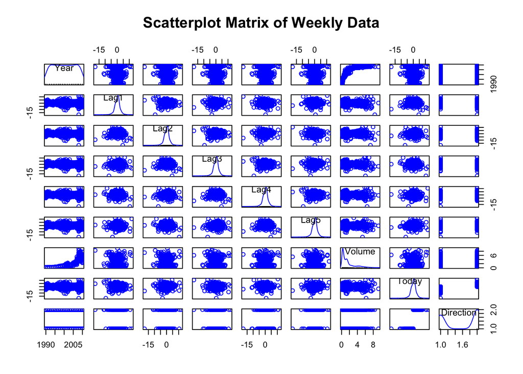

```r
scatterplotMatrix(~Year+Lag1+Lag2+Lag3+Lag4+Lag5+Volume+Today+Direction, data=Weekly,
                  smooth=FALSE, regLine=FALSE, ellipse=FALSE,
                  main="Scatterplot Matrix of Weekly Data")
```

The variables Year and Volume seem to be correlated. Volume increases as we move forward in time.

### Part b

```r
logmodel <- glm(Direction ~ Lag1 + Lag2 + Lag3 + Lag4 + Lag5 + Volume,
                data = Weekly, family = binomial())
summary(logmodel)
```

```
##
## Call:
## glm(formula = Direction ~ Lag1 + Lag2 + Lag3 + Lag4 + Lag5 +
##     Volume, family = binomial(), data = Weekly)
##
## Deviance Residuals:
##     Min       1Q   Median       3Q      Max
## -1.6949  -1.2565   0.9913   1.0849   1.4579
##
## Coefficients:
##             Estimate Std. Error z value Pr(>|z|)
## (Intercept)  0.26686    0.08593   3.106   0.0019 **
## Lag1        -0.04127    0.02641  -1.563   0.1181
## Lag2         0.05844    0.02686   2.175   0.0296 *
## Lag3        -0.01606    0.02666  -0.602   0.5469
## Lag4        -0.02779    0.02646  -1.050   0.2937
## Lag5        -0.01447    0.02638  -0.549   0.5833
## Volume      -0.02274    0.03690  -0.616   0.5377
## ---
## Signif. codes:  0 '***' 0.001 '**' 0.01 '*' 0.05 '.' 0.1 ' ' 1
##
## (Dispersion parameter for binomial family taken to be 1)
##
##     Null deviance: 1496.2  on 1088  degrees of freedom
## Residual deviance: 1486.4  on 1082  degrees of freedom
## AIC: 1500.4
##
## Number of Fisher Scoring iterations: 4
```

Out of all the predictors, only Lag2 has a p value that is less than the critical value at 95% confidence level. Hence, Lag2 appears to be the only predictor that is statistically significant.

### Part c

```r
logprob <- predict(logmodel, data=Weekly, type = "response")
logpred <- ifelse(logprob > 0.5, "Up", "Down")
table(logpred, Weekly$Direction)
```

```
##
## logpred Down  Up
##    Down   54  48
##    Up    430 557
```

```r
predrate <- (54+557)/1089
predrate
```

```
## [1] 0.5610652
```

The confusion matrix shows that the logistic regression model correctly predicted the Direction “Down” for 54 data points in the data set and wrongly predicted the direction “Up” for 430 data points that originally were classified as “Down”. Similarly, the model correctly predicted “Up” for 557 data points and wrongly predicted the direction “Down” for 48 points that were originally “Up”.

The accuracy rate of prediction by this model is 56.10%.

### Part d

```r
train = (Year<2009)
test = Weekly[!train,]
dim(test)
```

```
## [1] 104   9
```

```r
Direction.2009 = Direction[!train]
trainmodel = glm(Direction ~ Lag2, data = Weekly, family = binomial(), subset = train)
train.probs = predict(trainmodel, test, type = "response")
train.preds = rep("Down ", 104)
train.preds[train.probs >.5] = "Up"
table(train.preds, Direction.2009)
```

```
##            Direction.2009
## train.preds Down Up
##       Down     9  5
##       Up      34 56
```

```r
trainrate <- (9+56)/104
trainrate
```

```
## [1] 0.625
```

The overall fraction of correct predictions for the test data is 62.5%.

### Part e

```r
ldamodel <- lda(Direction ~ Lag2, data = Weekly, family = binomial(), subset = train)
lda.preds = predict(ldamodel, test)
lda.class = lda.preds$class
table(lda.class, Direction.2009)
```

```
##          Direction.2009
## lda.class Down Up
##      Down    9  5
##      Up     34 56
```

```r
ldarate <- (9+56)/104
ldarate
```

```
## [1] 0.625
```

The overall fraction of correct predictions by the LDA model for the test data is 62.5%.

### Part f

```r
qdamodel <- qda(Direction ~ Lag2, data = Weekly, family = binomial(), subset = train)
qda.preds = predict(qdamodel, test)
qda.class = qda.preds$class
table(qda.class, Direction.2009)
```

```
##          Direction.2009
## qda.class Down Up
##      Down    0  0
##      Up     43 61
```

```r
qdarate <- (61)/104
qdarate
```

```
## [1] 0.5865385
```

The fraction of correct predictions by the QDA model for the test data is 58.65%.

### Part g

```r
set.seed(1)
traindata = Weekly[train, ]
train.X = cbind(traindata$Lag2)
test.X = cbind(test$Lag2)
train.Direction = Direction[train]
knn.pred <- knn(train.X, test.X, traindata$Direction, k=1)
table(knn.pred, test$Direction)
```

```
##
## knn.pred Down Up
##     Down   21 30
##     Up     22 31
```

```r
knnrate <- (21+31)/104
knnrate
```

```
## [1] 0.5
```

The fraction of correct predictions by the KNN method with K = 1 for the test data is 50%.

### Part h

Judging by the overall prediction rates, logistic regression and LDA models seem to provide the best results. Both these methods produced accuracy rates of 62.5% while QDA produced 58.65% and KNN method produced 50%.

### Logistic Regression with Lag2*Volume as an interaction variable

```r
logmodel2 <- glm(Direction ~ Lag2*Volume,
                data = Weekly, family = binomial())
summary(logmodel2)
```

```
##
## Call:
## glm(formula = Direction ~ Lag2 * Volume, family = binomial(),
##     data = Weekly)
##
## Deviance Residuals:
##    Min      1Q  Median      3Q     Max
## -1.589  -1.269   1.015   1.084   1.474
##
## Coefficients:
##             Estimate Std. Error z value Pr(>|z|)
## (Intercept)  0.23724    0.08418   2.818  0.00483 **
## Lag2         0.05061    0.03911   1.294  0.19560
## Volume      -0.01297    0.03668  -0.354  0.72363
## Lag2:Volume  0.00415    0.01068   0.389  0.69764
## ---
## Signif. codes:  0 '***' 0.001 '**' 0.01 '*' 0.05 '.' 0.1 ' ' 1
##
## (Dispersion parameter for binomial family taken to be 1)
##
##     Null deviance: 1496.2  on 1088  degrees of freedom
## Residual deviance: 1490.1  on 1085  degrees of freedom
## AIC: 1498.1
##
## Number of Fisher Scoring iterations: 4
```

```r
logprob2 <- predict(logmodel2, data=Weekly, type = "response")
logpred2 <- ifelse(logprob2 > 0.5, "Up", "Down")
table(logpred2, Weekly$Direction)
```

```
##
## logpred2 Down  Up
##     Down   33  26
##     Up    451 579
```

```r
log2rate <- (33+579)/1089
log2rate
```

```
## [1] 0.5619835
```

I built a second logistic regression model with Lag2*Volume as an interaction variable. By looking at the confusion matrix, we can observe that the predictions are very similar to the first model’s predictions. The accuracy rate also increased by only 0.09%.

### KNN Method with K = 5

```r
knn.pred2 <- knn(train.X, test.X, traindata$Direction, k=5)
table(knn.pred2, test$Direction)
```

```
##
## knn.pred2 Down Up
##      Down   15 20
##      Up     28 41
```

```r
knnrate2 <- (15+41)/104
knnrate2
```

```
## [1] 0.5384615
```

### KNN Method with K = 10

```r
knn.pred3 <- knn(train.X, test.X, traindata$Direction, k=10)
table(knn.pred3, test$Direction)
```

```
##
## knn.pred3 Down Up
##      Down   17 19
##      Up     26 42
```

```r
knnrate3 <- (17+42)/104
knnrate3
```

```
## [1] 0.5673077
```

### KNN Method with K = 15

```r
knn.pred4 <- knn(train.X, test.X, traindata$Direction, k=15)
table(knn.pred4, test$Direction)
```

```
##
## knn.pred4 Down Up
##      Down   20 20
##      Up     23 41
```

```r
knnrate4 <- (20+41)/104
knnrate4
```

```
## [1] 0.5865385
```

```r
knn.pred5 <- knn(train.X, test.X, traindata$Direction, k=15)
table(knn.pred5, test$Direction)
```

```
##
## knn.pred5 Down Up
##      Down   20 20
##      Up     23 41
```

```r
knnrate5 <- (20+41)/104
knnrate5
```

```
## [1] 0.5865385
```

## Question 11

```r
data(Auto)
names(Auto)
```

```
## [1] "mpg"          "cylinders"    "displacement" "horsepower"
## [5] "weight"       "acceleration" "year"         "origin"
## [9] "name"
```

### Part a

```r
median <- median(Auto$mpg)
mpg01 <- ifelse(Auto$mpg > median, 1, 0)
Autodf <- data.frame(Auto, mpg01)
```

### Part b

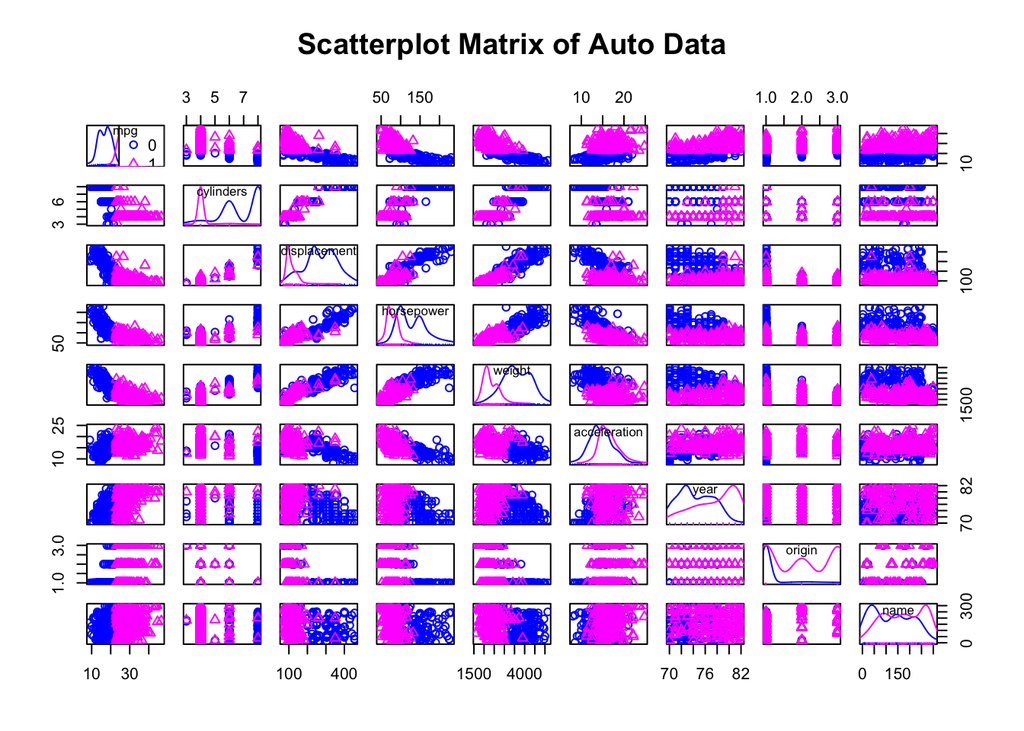

```r
scatterplotMatrix(~mpg+cylinders+displacement+horsepower+weight+acceleration+year+origin+name|mpg01,
                  data=Autodf, smooth=FALSE, regLine=FALSE, ellipse=FALSE,
                  main="Scatterplot Matrix of Auto Data")
```

In the plot, cars with mpg above the median are represented in pink and cars with mpg below the median (mpg01 = 0) are represented in blue. The variables displacement, horsepower and acceleration appear to be strongly correlated with mpg. The variable weight is also correlated to horsepower and displacement.

Cars with mpg below the median appear to have higher levels of horspower, displacement, weight and cylinders.

### Part c

```r
set.seed(1)
sample = floor(0.75*nrow(Autodf)) # setting 75% for training and 25% for testing
sample
```

```
## [1] 294
```

```r
train_id <- sample(seq_len(nrow(Autodf)),size = sample)
auto.train <- Autodf[train_id,]
auto.test <- Autodf[-train_id,]
```

### Part d

```r
set.seed(1)
auto.lda <- lda(mpg01~displacement+horsepower+acceleration+weight, data=auto.train)
auto.ldapred <- predict(auto.lda, auto.test)$class
table(auto.ldapred, auto.test$mpg01)
```

```
##
## auto.ldapred  0  1
##            0 39  1
##            1  7 51
```

```r
(7+1)/98
```

```
## [1] 0.08163265
```

The test error of the model is 8.16%.

### Part e

```r
set.seed(1)
auto.qda <- qda(mpg01~displacement+horsepower+acceleration+weight, data=auto.train)
auto.qdapred <- predict(auto.qda, auto.test)$class
table(auto.qdapred, auto.test$mpg01)
```

```
##
## auto.qdapred  0  1
##            0 39  3
##            1  7 49
```

```r
(7+3)/98
```

```
## [1] 0.1020408
```

### Part f

```r
set.seed(1)
auto.log <- glm(mpg01~displacement+horsepower+acceleration+weight, data=auto.train, family=binomial)
auto.logprob <- predict(auto.log, auto.test, type="response")
auto.logpred <- ifelse(auto.logprob > 0.5, 1, 0)
table(auto.logpred, auto.test$mpg01)
```

```
##
## auto.logpred  0  1
##            0 41  3
##            1  5 49
```

```r
(5+3)/98
```

```
## [1] 0.08163265
```

The test error of the model is 8.16%.

### K = 1

```r
set.seed(1)
autotrain.X <- cbind(auto.train$displacement, auto.train$horsepower, auto.train$weight, auto.train$acceleration)
autotest.X <- cbind(auto.test$displacement, auto.test$horsepower, auto.test$weight, auto.test$acceleration)
autoknn.pred <- knn(autotrain.X, autotest.X, auto.train$mpg01, k=1)
table(autoknn.pred, auto.test$mpg01)
```

```
##
## autoknn.pred  0  1
##            0 38  8
##            1  8 44
```

```r
(8+8)/98
```

```
## [1] 0.1632653
```

### K = 5

```r
set.seed(1)
autoknn.pred2 <- knn(autotrain.X, autotest.X, auto.train$mpg01, k=5)
table(autoknn.pred2, auto.test$mpg01)
```

```
##
## autoknn.pred2  0  1
##             0 36  3
##             1 10 49
```

```r
(10+3)/98
```

```
## [1] 0.1326531
```

### K = 10

```r
set.seed(1)
autoknn.pred3 <- knn(autotrain.X, autotest.X, auto.train$mpg01, k=10)
table(autoknn.pred3, auto.test$mpg01)
```

```
##
## autoknn.pred3  0  1
##             0 36  3
##             1 10 49
```

```r
(10+3)/98
```

```
## [1] 0.1326531
```

### K = 30

```r
set.seed(1)
autoknn.pred4 <- knn(autotrain.X, autotest.X, auto.train$mpg01, k=30)
table(autoknn.pred4, auto.test$mpg01)
```

```
##
## autoknn.pred4  0  1
##             0 41  2
##             1  5 50
```

```r
(5+2)/98
```

```
## [1] 0.07142857
```

### K = 50

```r
set.seed(1)
autoknn.pred5 <- knn(autotrain.X, autotest.X, auto.train$mpg01, k=50)
table(autoknn.pred5, auto.test$mpg01)
```

```
##
## autoknn.pred5  0  1
##             0 38  2
##             1  8 50
```

```r
(8+2)/98
```

```
## [1] 0.1020408
```

KNN method appears to produce the lowest test error rate for approximately K = 30.

## ISLR Chapter 5

## Question 2

### Part a

If a bootstrap is not the jth observation, then it could take on the value of any other observation from the original sample except the jth value.

Hence, probability that the first bootstrap observation is not the jth observation: (n-1)/n

### Part b

Similar to part a, if the second bootstrap isn’t the jth data point, it could be any of the other observations in the sample.

So, probability that the second bootstrap observation is not the jth observation: (n-1)/n

### Part c

Combining part a and part b:

If our bootstrap sample had only 2 iterations, then the probability for this case would be:

((2-1)/2)*((2-1)/2) = ((2-1)/2)^2

This can also be written as (1-1/2)^2. For nth iterations, the probability is: (1-1/n)^n

### Part d

When n = 5, Pr that jth is not in sample:

```r
(1-1/5)^5
```

```
## [1] 0.32768
```

Hence, Pr that jth is in sample:

```r
1- (1-1/5)^5
```

```
## [1] 0.67232
```

### Part e

When n = 100, Pr that jth is in sample:

```r
1 - ((1-1/100)^100)
```

```
## [1] 0.6339677
```

### Part f

When n = 10,000, Pr that jth is in sample:

```r
1 - ((1-1/10000)^10000)
```

```
## [1] 0.632139
```

### Part g

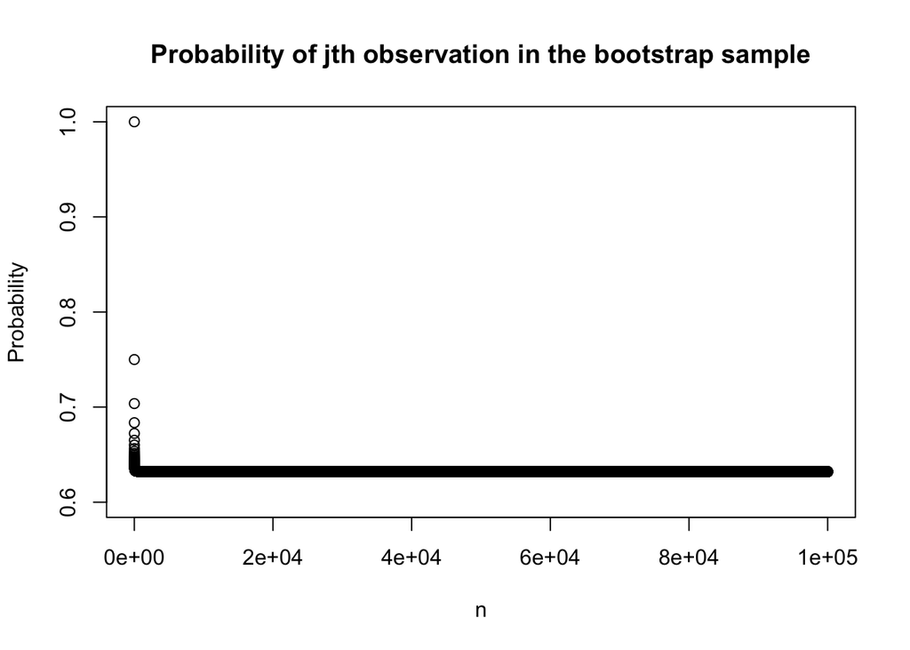

```r
n <- c(1:100000)
pr <- 1 - ((1-1/n)^n)
plot(n, pr, main = "Probability of jth observation in the bootstrap sample",
     xlab = "n", ylab = "Probability", ylim = c(0.6, 1.0))
```

### Part h

```r
store = rep(NA, 10000)
for(i in 1:10000) {
store[i] = sum(sample (1:100 , rep = TRUE) == 4) > 0
}
mean(store)
```

```
## [1] 0.6429
```

## Question 5

```r
set.seed(1)
data("Default")
attach(Default)
```

### Part a

```r
def.log <- glm(default ~ income + balance, data = Default, family = binomial)
```

### Part b

```r
set.seed(1)
def.train <- sample(10000, 6000) # setting 60% for training and 40% for testing
def.test <- Default[-def.train,]
def.log2 <- glm(default ~ income + balance, data=Default, family = binomial, subset = def.train)
def.probs <- predict(def.log2, def.test, type="response")
def.preds <- ifelse(def.probs > 0.5, "Yes", "No")
table(def.preds, def.test$default)
```

```
##
## def.preds   No  Yes
##       No  3852   92
##       Yes   19   37
```

```r
(19+92)/4000 # Misclassification Error
```

```
## [1] 0.02775
```

### Part c

#### Round 1

```r
set.seed(10)
def.train2 <- sample(10000, 6000) # setting 60% for training and 40% for testing
def.test2 <- Default[-def.train2,]
def.log3 <- glm(default ~ income + balance, data=Default, family = binomial, subset = def.train2)
def.probs2 <- predict(def.log3, def.test2, type="response")
def.preds2 <- ifelse(def.probs2 > 0.5, "Yes", "No")
table(def.preds2, def.test2$default)
```

```
##
## def.preds2   No  Yes
##        No  3849   95
##        Yes   15   41
```

```r
(15+95)/4000 # Misclassification Error
```

```
## [1] 0.0275
```

#### Round 2

```r
set.seed(20)
def.train3 <- sample(10000, 6000) # setting 60% for training and 40% for testing
def.test3 <- Default[-def.train3,]
def.log4 <- glm(default ~ income + balance, data=Default, family = binomial, subset = def.train3)
def.probs3 <- predict(def.log4, def.test3, type="response")
def.preds3 <- ifelse(def.probs3 > 0.5, "Yes", "No")
table(def.preds3, def.test3$default)
```

```
##
## def.preds3   No  Yes
##        No  3854   96
##        Yes   14   36
```

```r
(14+96)/4000 # Misclassification Error
```

```
## [1] 0.0275
```

#### Round 3

```r
set.seed(40)
def.train4 <- sample(10000, 6000) # setting 60% for training and 40% for testing
def.test4 <- Default[-def.train3,]
def.log5 <- glm(default ~ income + balance, data=Default, family = binomial, subset = def.train4)
def.probs4 <- predict(def.log5, def.test4, type="response")
def.preds4 <- ifelse(def.probs4 > 0.5, "Yes", "No")
table(def.preds4, def.test4$default)
```

```
##
## def.preds4   No  Yes
##        No  3853   95
##        Yes   15   37
```

```r
(15+95)/4000 # Misclassification Error
```

```
## [1] 0.0275
```

The validation error remains around 2.75% throughout the various rounds. This indicates that the variable default is not highly variant.

### Part d

```r
set.seed(5)
def.train5 <- sample(10000, 5000)
def.test5 <- Default[-def.train5, ]
def.fit <- glm(default ~ income + balance + student, data=Default, family=binomial, subset=def.train5)
def.probs5 <- predict(def.fit, def.test5, type="response")
def.preds5 <- ifelse(def.probs5 > 0.5, "Yes", "No")
table(def.preds5, def.test5$default)
```

```
##
## def.preds5   No  Yes
##        No  4820  113
##        Yes   15   52
```

```r
(15+113)/5000
```

```
## [1] 0.0256
```

The misclassification error for the model with the variable “student” is 2.56%. This is not a big drop in error rate when compared to the error rate of a model without student.

## Question 6

### Part a

A logistic model was fit in the previous question, Part a. Using the same model:

```r
summary(def.log)
```

```
##
## Call:
## glm(formula = default ~ income + balance, family = binomial,
##     data = Default)
##
## Deviance Residuals:
##     Min       1Q   Median       3Q      Max
## -2.4725  -0.1444  -0.0574  -0.0211   3.7245
##
## Coefficients:
##               Estimate Std. Error z value Pr(>|z|)
## (Intercept) -1.154e+01  4.348e-01 -26.545  < 2e-16 ***
## income       2.081e-05  4.985e-06   4.174 2.99e-05 ***
## balance      5.647e-03  2.274e-04  24.836  < 2e-16 ***
## ---
## Signif. codes:  0 '***' 0.001 '**' 0.01 '*' 0.05 '.' 0.1 ' ' 1
##
## (Dispersion parameter for binomial family taken to be 1)
##
##     Null deviance: 2920.6  on 9999  degrees of freedom
## Residual deviance: 1579.0  on 9997  degrees of freedom
## AIC: 1585
##
## Number of Fisher Scoring iterations: 8
```

The estimated standard errors for the coefficient is 4.985e-06 for income and 2.274e-04 for balance.

### Part b

```r
set.seed(1)
boot.fn = function(data, index) return(coef(glm(default ~ income + balance,
    data = data, family = binomial, subset = index)))
boot.fn(Default, sample(10000, 10000, replace =T))
```

```
##   (Intercept)        income       balance
## -1.115930e+01  2.134762e-05  5.419225e-03
```

### Part c

```r
boot(Default, boot.fn, 100)
```

```
##
## ORDINARY NONPARAMETRIC BOOTSTRAP
##
##
## Call:
## boot(data = Default, statistic = boot.fn, R = 100)
##
##
## Bootstrap Statistics :
##          original        bias     std. error
## t1* -1.154047e+01  8.304501e-02 4.173188e-01
## t2*  2.080898e-05  1.108172e-07 4.226986e-06
## t3*  5.647103e-03 -4.988227e-05 2.124724e-04
```

### Part d

Both the glm() and bootstrap functions give similar answers. The estimated standard errors for the coefficients only differ at the 7th decimal digit for income and the 4th decimal digit balance.

## Question 7

```r
data(Weekly)
```

### Part a

```r
w.log <- glm(Direction ~ Lag1 + Lag2, data = Weekly, family = binomial)
summary(w.log)
```

```
##
## Call:
## glm(formula = Direction ~ Lag1 + Lag2, family = binomial, data = Weekly)
##
## Deviance Residuals:
##    Min      1Q  Median      3Q     Max
## -1.623  -1.261   1.001   1.083   1.506
##
## Coefficients:
##             Estimate Std. Error z value Pr(>|z|)
## (Intercept)  0.22122    0.06147   3.599 0.000319 ***
## Lag1        -0.03872    0.02622  -1.477 0.139672
## Lag2         0.06025    0.02655   2.270 0.023232 *
## ---
## Signif. codes:  0 '***' 0.001 '**' 0.01 '*' 0.05 '.' 0.1 ' ' 1
##
## (Dispersion parameter for binomial family taken to be 1)
##
##     Null deviance: 1496.2  on 1088  degrees of freedom
## Residual deviance: 1488.2  on 1086  degrees of freedom
## AIC: 1494.2
##
## Number of Fisher Scoring iterations: 4
```

### Part b

```r
Weekly2 <- Weekly[-1, ]
w2.log <- glm(Direction ~ Lag1 + Lag2, data = Weekly2, family = binomial)
summary(w2.log)
```

```
##
## Call:
## glm(formula = Direction ~ Lag1 + Lag2, family = binomial, data = Weekly2)
##
## Deviance Residuals:
##     Min       1Q   Median       3Q      Max
## -1.6258  -1.2617   0.9999   1.0819   1.5071
##
## Coefficients:
##             Estimate Std. Error z value Pr(>|z|)
## (Intercept)  0.22324    0.06150   3.630 0.000283 ***
## Lag1        -0.03843    0.02622  -1.466 0.142683
## Lag2         0.06085    0.02656   2.291 0.021971 *
## ---
## Signif. codes:  0 '***' 0.001 '**' 0.01 '*' 0.05 '.' 0.1 ' ' 1
##
## (Dispersion parameter for binomial family taken to be 1)
##
##     Null deviance: 1494.6  on 1087  degrees of freedom
## Residual deviance: 1486.5  on 1085  degrees of freedom
## AIC: 1492.5
##
## Number of Fisher Scoring iterations: 4
```

### Part c

```r
predict(w2.log, Weekly[1, ], type = "response") > 0.5
```

```
##    1
## TRUE
```

The predicted probability for Direction is over 0.5. Hence, the model predicts the direction of the first observation as “Up”. However, the first observation in the Weekly data set for direction is “Down”. Hence, this observation is wrongly classified.

### Part d

```r
loocv.error <- rep(0, nrow(Weekly))
for (i in 1:nrow(Weekly)) {
  model <- glm(Direction ~ Lag1 + Lag2, data=Weekly[-i,], family=binomial)
  prob <- ifelse(predict.glm(model, Weekly[i,], type="response") > 0.5, "Up", "Down")
  loocv.error[i] <- ifelse(Weekly[i,]$Direction==prob, 0, 1)
}
```

### Part e

```r
mean(loocv.error)
```

```
## [1] 0.4499541
```

The LOOCV estimate for the test error is 0.4499. This method gives a high error rate for prediction, indicating that this method might not be optimal.